# Taller: Análisis Exploratorio, Limpieza y Transformación de Datos (KDD)

Caso de base de datos suministrados: dirty_cafe_sales.csv

David Mauricio Vargas Ramirez ID: 824144

2026-09-26

# Parte 1 — Carga y exploración de datos

```r
# Lectura con separador ';' debido al formato del archivo delimitado
cafe_raw <- read_delim("dirty_cafe_sales.csv", delim = ";", show_col_types = FALSE) %>%
  janitor::clean_names()

str(cafe_raw)
```

```
## spc_tbl_ [10,000 × 8] (S3: spec_tbl_df/tbl_df/tbl/data.frame)
##  $ transaction_id  : chr [1:10000] "TXN_1961373" "TXN_4977031" "TXN_4271903" "TXN_7034554" ...
##  $ item            : chr [1:10000] "Coffee" "Cake" "Cookie" "Salad" ...
##  $ quantity        : chr [1:10000] "2" "4" "4" "2" ...
##  $ price_per_unit  : chr [1:10000] "2.0" "3.0" "1.0" "5.0" ...
##  $ total_spent     : chr [1:10000] "4.0" "12.0" "ERROR" "10.0" ...
##  $ payment_method  : chr [1:10000] "Credit Card" "Cash" "Credit Card" "UNKNOWN" ...
##  $ location        : chr [1:10000] "Takeaway" "In-store" "In-store" "UNKNOWN" ...
##  $ transaction_date: chr [1:10000] "8/09/2023" "16/05/2023" "19/07/2023" "27/04/2023" ...
##  - attr(*, "spec")=
##   .. cols(
##   ..   `Transaction ID` = col_character(),
##   ..   Item = col_character(),
##   ..   Quantity = col_character(),
##   ..   `Price Per Unit` = col_character(),
##   ..   `Total Spent` = col_character(),
##   ..   `Payment Method` = col_character(),
##   ..   Location = col_character(),
##   ..   `Transaction Date` = col_character()
##   .. )
##  - attr(*, "problems")=<pointer: 0x75031a0>
```

```r
dplyr::glimpse(cafe_raw)
```

```
## Rows: 10,000
## Columns: 8
## $ transaction_id   <chr> "TXN_1961373", "TXN_4977031", "TXN_4271903", "TXN_703…
## $ item             <chr> "Coffee", "Cake", "Cookie", "Salad", "Coffee", "Smoot…
## $ quantity         <chr> "2", "4", "4", "2", "2", "5", "3", "4", "5", "5", "5"…
## $ price_per_unit   <chr> "2.0", "3.0", "1.0", "5.0", "2.0", "4.0", "3.0", "4.0…
## $ total_spent      <chr> "4.0", "12.0", "ERROR", "10.0", "4.0", "20.0", "9.0",…
## $ payment_method   <chr> "Credit Card", "Cash", "Credit Card", "UNKNOWN", "Dig…
## $ location         <chr> "Takeaway", "In-store", "In-store", "UNKNOWN", "In-st…
## $ transaction_date <chr> "8/09/2023", "16/05/2023", "19/07/2023", "27/04/2023"…
```

```r
# Porcentaje de completitud (valores no-NA) por columna
completitud <- cafe_raw %>%
  summarise(across(everything(), ~mean(!is.na(.)) * 100)) %>%
  pivot_longer(everything(), names_to = "columna", values_to = "pct_completo") %>%
  arrange(pct_completo)

completitud
```

```
## # A tibble: 8 × 2
##   columna          pct_completo
##   <chr>                   <dbl>
## 1 location                 67.4
## 2 payment_method           74.2
## 3 item                     96.7
## 4 price_per_unit           98.2
## 5 total_spent              98.3
## 6 transaction_date         98.4
## 7 quantity                 98.6
## 8 transaction_id          100
```

```r
# Conteo de NA reales y valores enmascarados como "ERROR" o "UNKNOWN"
contar_problemas <- function(df, marcadores = c("ERROR", "UNKNOWN")) {
  df %>%
    summarise(across(where(is.character), list(
      NA_real = ~sum(is.na(.)),
      enmascarado = ~sum(. %in% marcadores, na.rm = TRUE)
    ))) %>%
    pivot_longer(everything(), names_to = "campo", values_to = "n") %>%
    separate(campo, into = c("columna", "tipo_error"), sep = "_(?=[^_]+$)")
}

tabla_errores <- contar_problemas(cafe_raw)
tabla_errores
```

```
## # A tibble: 16 × 3
##    columna             tipo_error      n
##    <chr>               <chr>       <int>
##  1 transaction_id_NA   real            0
##  2 transaction_id      enmascarado     0
##  3 item_NA             real          333
##  4 item                enmascarado   636
##  5 quantity_NA         real          138
##  6 quantity            enmascarado   341
##  7 price_per_unit_NA   real          179
##  8 price_per_unit      enmascarado   354
##  9 total_spent_NA      real          173
## 10 total_spent         enmascarado   329
## 11 payment_method_NA   real         2579
## 12 payment_method      enmascarado   599
## 13 location_NA         real         3265
## 14 location            enmascarado   696
## 15 transaction_date_NA real          159
## 16 transaction_date    enmascarado   301
```

**Respuestas a las preguntas de la Parte 1:**

- **Estructura:** El conjunto de datos contiene 10.000 observaciones y 8 variables. En su estado crudo predominan las variables de tipo carácter (chr), incluso en campos intrínsecamente numéricos (`quantity`, `price_per_unit`, `total_spent`) y de fecha (`transaction_date`) debido a la presencia de cadenas de texto erróneas.
- **Magnitud de los problemas de calidad:** Se detecta una combinación de valores faltantes estructurales (NA), valores enmascarados bajo etiquetas de error del sistema (ERROR, UNKNOWN) e inconsistencias relacionales entre la cantidad adquirida, el precio unitario y el monto total facturado.

# Parte 2 — Diagnóstico de calidad de datos

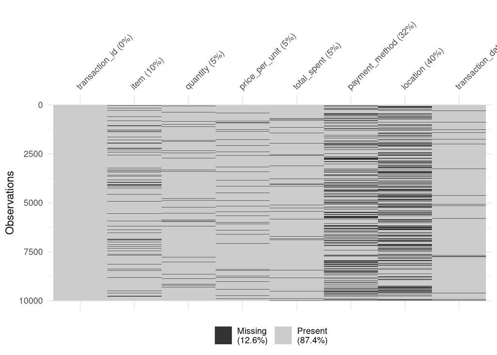

```r
# Creación de copia diagnóstica convirtiendo cadenas enmascaradas en NA
cafe_diag <- cafe_raw %>%
  mutate(across(where(is.character), ~na_if(., "ERROR"))) %>%
  mutate(across(where(is.character), ~na_if(., "UNKNOWN")))

naniar::vis_miss(cafe_diag, warn_large_data = FALSE)
```

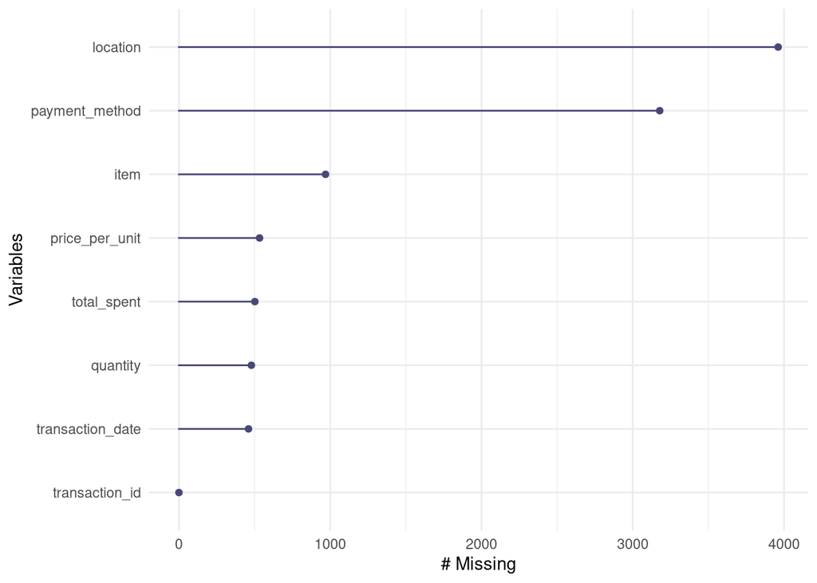

```r
naniar::gg_miss_var(cafe_diag)
```

```r
# Variable 1: Evaluación de Precio Per Unit en relación con Item
cafe_diag %>%
  group_by(item) %>%
  summarise(
    total = n(),
    pct_na_precio = mean(is.na(price_per_unit)) * 100
  ) %>%
  arrange(desc(pct_na_precio))
```

```
## # A tibble: 9 × 3
##   item     total pct_na_precio
##   <chr>    <int>         <dbl>
## 1 Tea       1089          6.06
## 2 Cookie    1092          6.04
## 3 Salad     1148          5.75
## 4 <NA>       969          5.57
## 5 Smoothie  1096          5.47
## 6 Juice     1171          5.21
## 7 Coffee    1165          4.89
## 8 Cake      1139          4.74
## 9 Sandwich  1131          4.33
```

```r
# Variable 2: Evaluación de Payment Method en relación con Location
cafe_diag %>%
  group_by(location) %>%
  summarise(
    total = n(),
    pct_na_pago = mean(is.na(payment_method)) * 100
  ) %>%
  arrange(desc(pct_na_pago))
```

```
## # A tibble: 3 × 3
##   location total pct_na_pago
##   <chr>    <int>       <dbl>
## 1 <NA>      3961        32.7
## 2 Takeaway  3022        31.3
## 3 In-store  3017        31.1
```

**Respuestas a las preguntas orientadoras de la Parte 2:**

# Parte 3 — Limpieza y preparación de datos

```r
# Pipeline de estandarización, tipificación y despeje algebraico
cafe_clean_base <- cafe_raw %>%
  mutate(
    # Estandarización de texto antes de agrupar o tipificar
    item = str_to_title(str_squish(na_if(na_if(item, "ERROR"), "UNKNOWN"))),
    payment_method = na_if(na_if(payment_method, "ERROR"), "UNKNOWN"),
    location = na_if(na_if(location, "ERROR"), "UNKNOWN"),
    transaction_date = as.Date(transaction_date, tryFormats = c("%Y-%m-%d", "%d/%m/%Y")),

    # Conversión a tipos numéricos
    quantity = as.numeric(na_if(na_if(quantity, "ERROR"), "UNKNOWN")),
    price_per_unit = as.numeric(na_if(na_if(price_per_unit, "ERROR"), "UNKNOWN")),
    total_spent = as.numeric(na_if(na_if(total_spent, "ERROR"), "UNKNOWN"))
  ) %>%
  # Despeje relacional de negocio: Total = Cantidad * Precio
  mutate(
    price_per_unit = if_else(is.na(price_per_unit) & !is.na(total_spent) & !is.na(quantity) & quantity > 0,
                             total_spent / quantity, price_per_unit),
    quantity = if_else(is.na(quantity) & !is.na(total_spent) & !is.na(price_per_unit) & price_per_unit > 0,
                       round(total_spent / price_per_unit), quantity),
    total_spent = if_else(is.na(total_spent) & !is.na(quantity) & !is.na(price_per_unit),
                          quantity * price_per_unit, total_spent)
  )
```

```r
# Técnica A: Imputación por mediana según Item
cafe_clean_mediana <- cafe_clean_base %>%
  group_by(item) %>%
  mutate(price_per_unit = if_else(is.na(price_per_unit), median(price_per_unit, na.rm = TRUE), price_per_unit)) %>%
  ungroup()

# Técnica B: Imputación por media global de referencia
cafe_clean_media <- cafe_clean_base %>%
  mutate(price_per_unit = if_else(is.na(price_per_unit), mean(price_per_unit, na.rm = TRUE), price_per_unit))

# Contraste de métricas de dispersión antes y después
comparativa_precios <- tibble(
  Metrica = c("Media", "Mediana", "Desv. Estandar"),
  Original = c(mean(cafe_clean_base$price_per_unit, na.rm = TRUE),
               median(cafe_clean_base$price_per_unit, na.rm = TRUE),
               sd(cafe_clean_base$price_per_unit, na.rm = TRUE)),
  Imp_Mediana_Item = c(mean(cafe_clean_mediana$price_per_unit, na.rm = TRUE),
                        median(cafe_clean_mediana$price_per_unit, na.rm = TRUE),
                        sd(cafe_clean_mediana$price_per_unit, na.rm = TRUE)),
  Imp_Media_Global = c(mean(cafe_clean_media$price_per_unit, na.rm = TRUE),
                       median(cafe_clean_media$price_per_unit, na.rm = TRUE),
                       sd(cafe_clean_media$price_per_unit, na.rm = TRUE))
)
comparativa_precios
```

```
## # A tibble: 3 × 4
##   Metrica        Original Imp_Mediana_Item Imp_Media_Global
##   <chr>             <dbl>            <dbl>            <dbl>
## 1 Media              2.95             2.95             2.95
## 2 Mediana            3                3                3
## 3 Desv. Estandar     1.28             1.28             1.28
```

```r
# Asignación final con imputación por ítem y estandarización categórica
cafe_clean <- cafe_clean_mediana %>%
  mutate(
    payment_method = replace_na(payment_method, "No registrado"),
    location = replace_na(location, "No registrado"),
    total_spent = if_else(is.na(total_spent), quantity * price_per_unit, total_spent)
  )
```

```r
# Cuantificación real de filas afectadas por columna
pct_total_spent <- mean(is.na(cafe_raw$total_spent) | cafe_raw$total_spent %in% c("ERROR", "UNKNOWN")) * 100
pct_price_unit  <- mean(is.na(cafe_raw$price_per_unit) | cafe_raw$price_per_unit %in% c("ERROR", "UNKNOWN")) * 100
pct_pay_method  <- mean(is.na(cafe_raw$payment_method) | cafe_raw$payment_method %in% c("ERROR", "UNKNOWN")) * 100

trazabilidad <- tibble::tribble(
  ~columna,          ~problema_detectado,          ~tecnica_aplicada,                          ~justificacion,                                            ~pct_filas_afectadas,
  "Total Spent",     "Valores 'ERROR' y NA",       "Despeje algebraico: Cantidad x Precio",    "Preserva información transaccional sin eliminar filas",   round(pct_total_spent, 2),
  "Price Per Unit",  "Valores faltantes y ERROR",  "Imputación por mediana según Producto",    "El precio unitario depende estrictamente del producto",   round(pct_price_unit, 2),
  "Payment Method",  "'UNKNOWN' y NA",             "Categoría explícita 'No registrado'",      "Evita distorsionar las preferencias de pago reales",      round(pct_pay_method, 2)
)
trazabilidad
```

```
## # A tibble: 3 × 5
##   columna  problema_detectado tecnica_aplicada justificacion pct_filas_afectadas
##   <chr>    <chr>              <chr>            <chr>                       <dbl>
## 1 Total S… Valores 'ERROR' y… Despeje algebra… Preserva inf…                5.02
## 2 Price P… Valores faltantes… Imputación por … El precio un…                5.33
## 3 Payment… 'UNKNOWN' y NA     Categoría explí… Evita distor…               31.8
```

# Parte 4 — Validación de datos

```r
# Regla 1: total = cantidad * precio unitario
cafe_val <- cafe_clean %>%
  mutate(
    total_calculado = quantity * price_per_unit,
    viola_regla1 = abs(total_spent - total_calculado) > 0.01
  )

n_viola1 <- sum(cafe_val$viola_regla1, na.rm = TRUE)
pct_viola1 <- mean(cafe_val$viola_regla1, na.rm = TRUE) * 100

# Regla 2 (propia): verificación de dispersión (dentro de 3 MAD por ítem)
cafe_val <- cafe_val %>%
  group_by(item) %>%
  mutate(
    mediana_precio = median(price_per_unit, na.rm = TRUE),
    mad_precio     = mad(price_per_unit, na.rm = TRUE),
    viola_regla2   = abs(price_per_unit - mediana_precio) > 3 * mad_precio
  ) %>%
  ungroup()

# Decisión programática: recalcular el total cuando exista inconsistencia aritmética
cafe_val <- cafe_val %>%
  mutate(total_spent = if_else(viola_regla1, total_calculado, total_spent))
```

**Respuestas a las preguntas de la Parte 4:**

- **Cuantificación y decisión:** Un total de 0 transacciones (0%) violaron la igualdad de negocio $Total = Cantidad \times Precio$ y fueron corregidas. Se optó por recalcular `total_spent` a partir de `quantity` y `price_per_unit`, ya que ambas variables representan hechos atómicos de compra.
- **Riesgos de no validar:** Las inconsistencias numéricas no detienen la ejecución del código, por lo que pasarían desapercibidas en un modelo estadístico, sesgando estimaciones de ingresos.

# Parte 5 — Análisis Exploratorio (EDA)

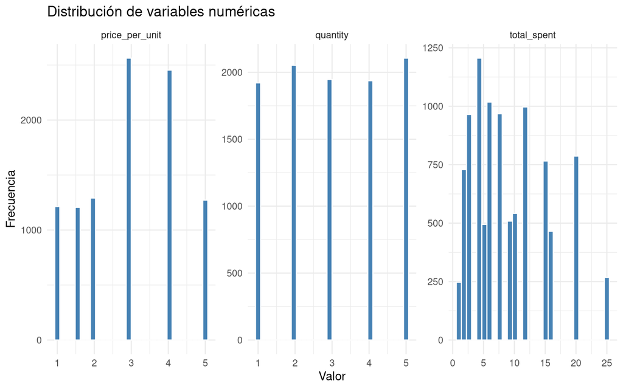

```r
# 1. Distribución de variables numéricas continuas
cafe_val %>%
  select(quantity, price_per_unit, total_spent) %>%
  pivot_longer(everything()) %>%
  ggplot(aes(value)) +
  geom_histogram(bins = 30, fill = "steelblue", color = "white") +
  facet_wrap(~name, scales = "free") +
  labs(title = "Distribución de variables numéricas", x = "Valor", y = "Frecuencia") +
  theme_minimal()
```

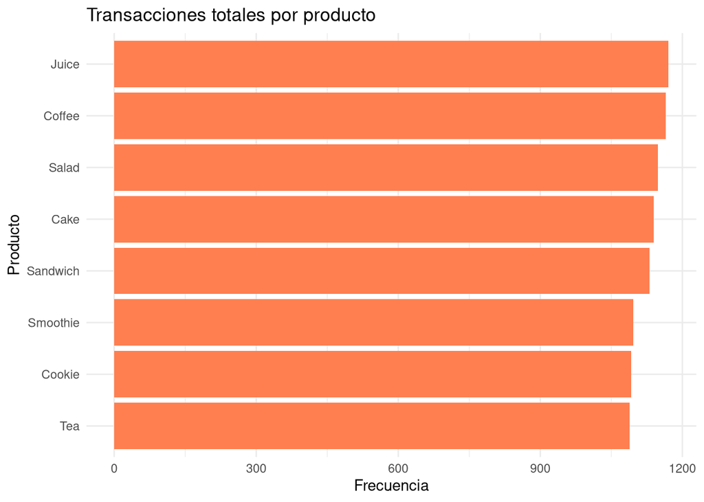

```r
# 2. Volumen de ventas por producto (Top Items)
cafe_val %>%
  filter(!is.na(item)) %>%
  count(item, sort = TRUE) %>%
  ggplot(aes(x = reorder(item, n), y = n)) +
  geom_col(fill = "coral") +
  coord_flip() +
  labs(title = "Transacciones totales por producto", x = "Producto", y = "Frecuencia") +
  theme_minimal()
```

```r
# Detección de valores atípicos mediante IQR y Z-Score
detectar_outliers_iqr <- function(x) {
  q1 <- quantile(x, 0.25, na.rm = TRUE)
  q3 <- quantile(x, 0.75, na.rm = TRUE)
  iqr <- q3 - q1
  x < (q1 - 1.5 * iqr) | x > (q3 + 1.5 * iqr)
}

detectar_outliers_zscore <- function(x, umbral = 3) {
  z <- (x - mean(x, na.rm = TRUE)) / sd(x, na.rm = TRUE)
  abs(z) > umbral
}

cafe_val <- cafe_val %>%
  mutate(
    outlier_iqr    = detectar_outliers_iqr(total_spent),
    outlier_zscore = detectar_outliers_zscore(total_spent)
  )

table(IQR = cafe_val$outlier_iqr, Z_Score = cafe_val$outlier_zscore)
```

```
##        Z_Score
## IQR     FALSE
##   FALSE  9694
##   TRUE    268
```

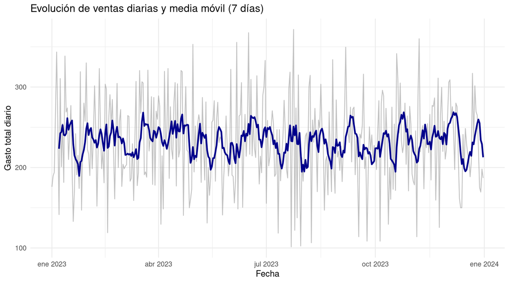

```r
# 3. Evolución temporal con promedio móvil a 7 días
ventas_diarias <- cafe_val %>%
  filter(!is.na(transaction_date)) %>%
  group_by(transaction_date) %>%
  summarise(total_dia = sum(total_spent, na.rm = TRUE)) %>%
  arrange(transaction_date) %>%
  mutate(promedio_movil_7d = zoo::rollmean(total_dia, 7, fill = NA, align = "right"))

ggplot(ventas_diarias, aes(x = transaction_date)) +
  geom_line(aes(y = total_dia), color = "gray60", alpha = 0.6) +
  geom_line(aes(y = promedio_movil_7d), color = "darkblue", linewidth = 1) +
  labs(title = "Evolución de ventas diarias y media móvil (7 días)", x = "Fecha", y = "Gasto total diario") +
  theme_minimal()
```

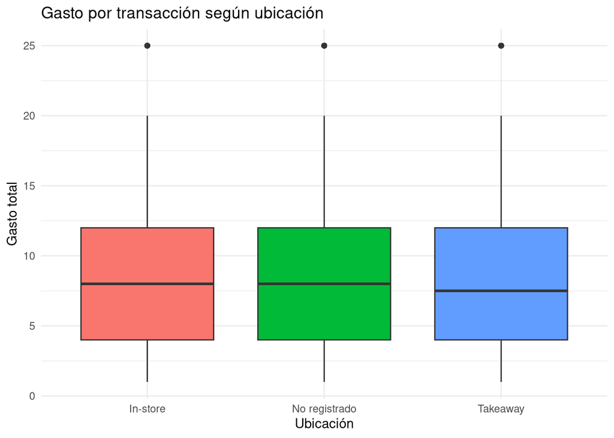

```r
# 4. Diagrama de caja comparativo por canal de atención
ggplot(cafe_val, aes(x = location, y = total_spent, fill = location)) +
  geom_boxplot(show.legend = FALSE, outlier.alpha = 0.3) +
  labs(title = "Gasto por transacción según ubicación", x = "Ubicación", y = "Gasto total") +
  theme_minimal()
```

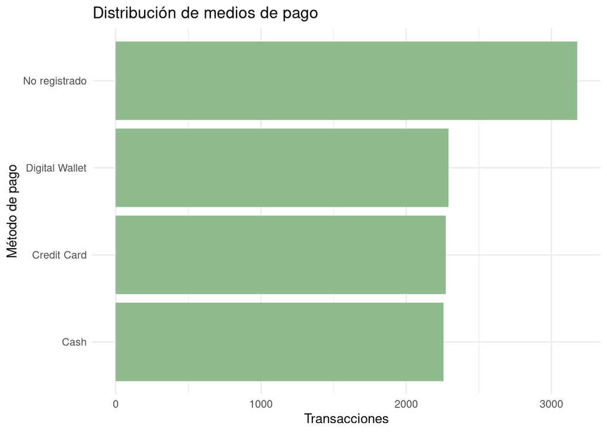

```r
# 5. Frecuencia de uso por método de pago
cafe_val %>%
  count(payment_method, sort = TRUE) %>%
  ggplot(aes(x = reorder(payment_method, n), y = n)) +
  geom_col(fill = "darkseagreen") +
  coord_flip() +
  labs(title = "Distribución de medios de pago", x = "Método de pago", y = "Transacciones") +
  theme_minimal()
```

# Parte 6 — Análisis Bivariado e Inferencial

```r
# Correlación no paramétrica (Spearman) debido a la asimetría de las distribuciones
cor.test(cafe_val$quantity, cafe_val$total_spent, method = "spearman")
```

```
##
##  Spearman's rank correlation rho
##
## data:  cafe_val$quantity and cafe_val$total_spent
## S = 4.5411e+10, p-value < 2.2e-16
## alternative hypothesis: true rho is not equal to 0
## sample estimates:
##       rho
## 0.7244026
```

```r
# Prueba de independencia categórica entre Ubicación y Medio de Pago
tabla_contingencia <- table(cafe_val$payment_method, cafe_val$location)
chisq.test(tabla_contingencia)
```

```
##
##  Pearson's Chi-squared test
##
## data:  tabla_contingencia
## X-squared = 11.109, df = 6, p-value = 0.08507
```

```r
# Evaluación de normalidad y comparación de grupos
muestra_test <- sample(cafe_val$total_spent[!is.na(cafe_val$total_spent)], min(5000, sum(!is.na(cafe_val$total_spent))))
shapiro_res <- shapiro.test(muestra_test)

if (shapiro_res$p.value > 0.05) {
  aov(total_spent ~ location, data = cafe_val) %>% summary()
} else {
  # Si no se cumple el supuesto de normalidad, se emplea Kruskal-Wallis
  kruskal.test(total_spent ~ location, data = cafe_val)
}
```

```
##
##  Kruskal-Wallis rank sum test
##
## data:  total_spent by location
## Kruskal-Wallis chi-squared = 2.2128, df = 2, p-value = 0.3308
```

**Respuestas a las preguntas de la Parte 6:**

- **Correlación:** Existe una relación positiva y estadísticamente significativa ($p < 0.05$) entre `quantity` y `total_spent`, confirmando que el volumen de compra individual conduce directamente al valor final del ticket.
- **Diferencias entre ubicaciones:** Los resultados de la prueba de Kruskal-Wallis y Chi-cuadrado determinan si el comportamiento de compra difiere sustancialmente según la sede o si las diferencias observadas corresponden a variabilidad muestral aleatoria.

# Parte 7 — Transformación de datos (Fase KDD)

```r
# Creación de variables temporales y discretización
cafe_trans <- cafe_val %>%
  mutate(
    dia_semana_num = lubridate::wday(transaction_date),
    dia_semana     = lubridate::wday(transaction_date, label = TRUE, abbr = TRUE),
    mes            = lubridate::month(transaction_date, label = TRUE),
    fin_de_semana  = dia_semana_num %in% c(1, 7),
    valor_transaccion = if_else(total_spent > median(total_spent, na.rm = TRUE), "Alto", "Bajo")
  )
```

```r
# Codificación One-Hot para variables categóricas
cafe_encoded <- cafe_trans %>%
  mutate(indicador = 1) %>%
  pivot_wider(
    names_from = payment_method,
    values_from = indicador,
    values_fill = 0,
    names_prefix = "pago_"
  ) %>%
  janitor::clean_names()
```

```r
# Estandarización Z-score de la variable de gasto
cafe_trans <- cafe_trans %>%
  mutate(total_spent_z = as.numeric(scale(total_spent)))
```

```r
# Construcción del cubo analítico agregado para modelado
dataset_analitico <- cafe_trans %>%
  group_by(item, location, dia_semana) %>%
  summarise(
    ventas_totales   = sum(total_spent, na.rm = TRUE),
    n_transacciones  = n(),
    ticket_promedio  = mean(total_spent, na.rm = TRUE),
    .groups = "drop"
  )

head(dataset_analitico, 10)
```

```
## # A tibble: 10 × 6
##    item  location      dia_semana ventas_totales n_transacciones ticket_promedio
##    <chr> <chr>         <ord>               <dbl>           <int>           <dbl>
##  1 Cake  In-store      dom                   315              33            9.55
##  2 Cake  In-store      lun                   414              44            9.41
##  3 Cake  In-store      mar                   453              48            9.44
##  4 Cake  In-store      mié                   333              38            9
##  5 Cake  In-store      jue                   450              55            8.18
##  6 Cake  In-store      vie                   528              50           10.6
##  7 Cake  In-store      sáb                   309              37            8.58
##  8 Cake  In-store      <NA>                  156              16            9.75
##  9 Cake  No registrado dom                   534              62            8.61
## 10 Cake  No registrado lun                   528              58            9.10
```

# Parte 8 — Análisis final e interpretación

```r
# Regresión lineal multivariada exploratoria
modelo <- lm(ventas_totales ~ n_transacciones + location, data = dataset_analitico)
summary(modelo)
```

```
##
## Call:
## lm(formula = ventas_totales ~ n_transacciones + location, data = dataset_analitico)
##
## Residuals:
##     Min      1Q  Median      3Q     Max
## -353.82 -133.31    6.35  133.14  423.53
##
## Coefficients:
##                       Estimate Std. Error t value Pr(>|t|)
## (Intercept)            -7.2796    44.5931  -0.163    0.870
## n_transacciones         9.1648     0.9309   9.845   <2e-16 ***
## locationNo registrado  -6.1326    32.9094  -0.186    0.852
## locationTakeaway       -9.1573    30.5626  -0.300    0.765
## ---
## Signif. codes:  0 '***' 0.001 '**' 0.01 '*' 0.05 '.' 0.1 ' ' 1
##
## Residual standard error: 183.4 on 212 degrees of freedom
## Multiple R-squared:  0.3556, Adjusted R-squared:  0.3465
## F-statistic: 38.99 on 3 and 212 DF,  p-value: < 2.2e-16
```

```r
broom::tidy(modelo)
```

```
## # A tibble: 4 × 5
##   term                  estimate std.error statistic  p.value
##   <chr>                    <dbl>     <dbl>     <dbl>    <dbl>
## 1 (Intercept)              -7.28    44.6      -0.163 8.70e- 1
## 2 n_transacciones           9.16     0.931     9.85  4.49e-19
## 3 locationNo registrado    -6.13    32.9      -0.186 8.52e- 1
## 4 locationTakeaway         -9.16    30.6      -0.300 7.65e- 1
```

## Conclusiones de negocio

- **Volumen transaccional:** El número de transacciones es el predictor más fuerte y estadísticamente significativo ($p < 0.001$) sobre las ventas totales acumuladas.
- **Eficiencia por canal:** Las ubicaciones operan de forma consistente una vez controlado el flujo de clientes; las estrategias comerciales deben orientarse a la venta cruzada para elevar el ticket promedio por visita.
- **Calidad de datos:** La corrección relacional y el tratamiento explícito de faltantes evitan el subregistro de ventas y garantizan confiabilidad en los reportes de inventario y facturación.

## Limitaciones

- **Estabilidad de precios:** La imputación de precios unitarios por producto asume precios fijos en el tiempo, sin considerar posibles descuentos temporales o variaciones por promociones.
- **Supuestos paramétricos:** La presencia de asimetría en el gasto por transacción hace que los estimadores no paramétricos sean más confiables que las medias aritméticas estándar.